# Joint Headline HICP — 4-component Bayesian VAR with SV, outliers and monthly seasonal dummies

## 17. Structural analysis — recursive IRFs, FEVD and historical decomposition

The structural block uses the engine's **recursive (Cholesky) identification** with the fixed contemporaneous ordering

[ Energy \rightarrow Food \rightarrow NEIG \rightarrow Services. ]

This is an identifying assumption, not a causal fact. Results are therefore ordering-dependent and should be interpreted as a recursive structural decomposition of the four-variable system. No structural label is inferred from a reduced-form cross-lag coefficient.

For IRFs and FEVD, shocks are regular one-standard-deviation structural innovations evaluated at the last balanced stochastic-volatility state; the transitory outlier multiplier is excluded. IRFs are shown as cumulative log-price responses (multiplied by 100). For the historical decomposition, the time-varying outlier scale is included so that the decomposition reconstructs the realised monthly changes exactly. Seasonal dummies are part of the deterministic/base contribution, not structural shocks.

To keep the notebook practical, the structural section uses a deterministic, evenly spaced subset of at most `STRUCTURAL_DRAWS` retained posterior draws. This thins only the presentation diagnostics; it does not alter the fitted posterior or forecasts.

```
Structural posterior draws: 1000 / 3000
Identification: recursive
SV reference date: 2026-06-01 00:00:00
Shock ordering: ['Energy', 'Food', 'NEIG', 'Services']
```

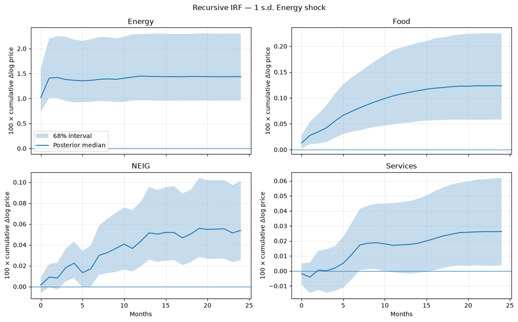

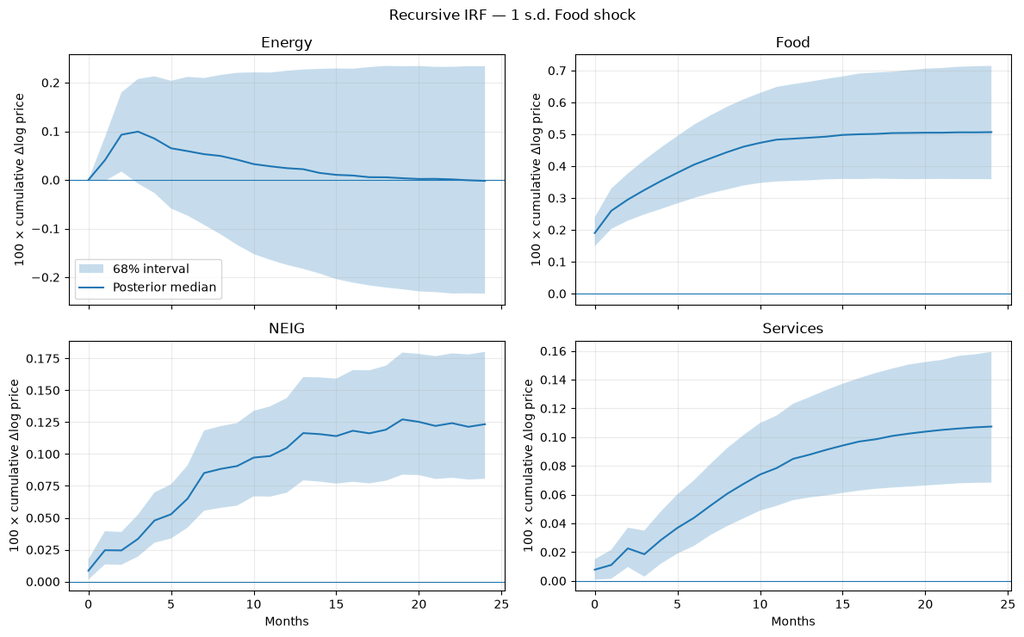

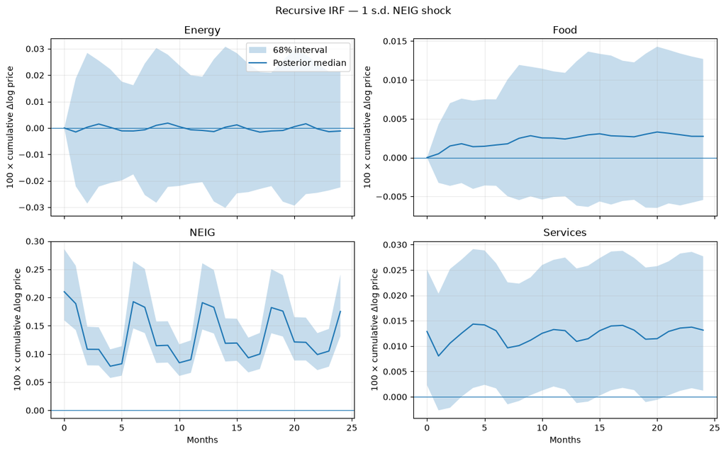

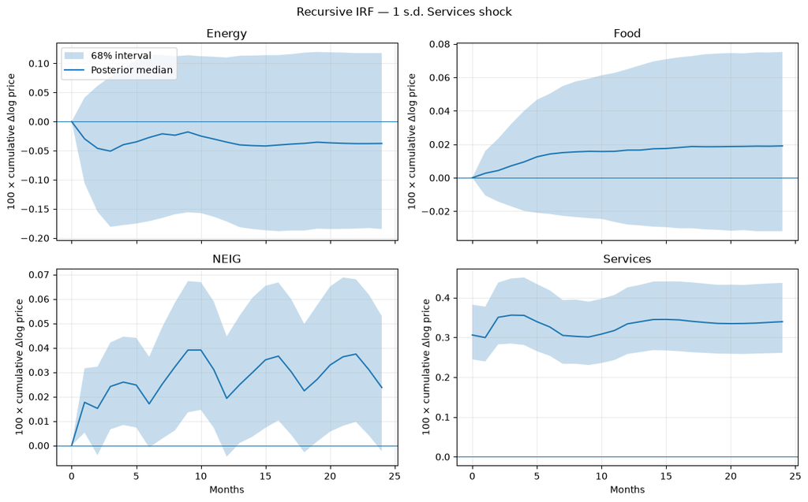

```python
if RUN_STRUCTURAL_ANALYSIS:
    structural_result = posterior_draw_subset(result_12, STRUCTURAL_DRAWS)
    print(
        "Structural posterior draws:", structural_result["n_draws"],
        "/", result_12["n_draws"],
    )

    structural_labels = {
        "state__hicp_energy": "Energy",
        "state__hicp_food": "Food",
        "state__hicp_neig": "NEIG",
        "state__hicp_services": "Services",
    }

    irf = impulse_responses(
        structural_result,
        identification="recursive",
        horizon=STRUCTURAL_HORIZON,
        shock_unit="structural_std",
        shock_size=1.0,
        include_outlier_scale=False,
    )

    print("Identification:", irf["identification"])
    print("SV reference date:", irf["reference_date"])
    print("Shock ordering:", [structural_labels[x] for x in irf["shock_names"]])

    horizons = np.asarray(irf["horizons"], dtype=int)
    cumulative = 100.0 * np.asarray(irf["cumulative_level_irfs"], dtype=float)

    for shock_j, shock_name in enumerate(irf["shock_names"]):
        fig, axes = plt.subplots(2, 2, figsize=(12, 7.5), sharex=True)
        for response_i, (ax, response_name) in enumerate(zip(axes.ravel(), irf["variables"])):
            q16, q50, q84 = np.percentile(
                cumulative[:, :, response_i, shock_j],
                [16, 50, 84],
                axis=0,
            )
            ax.fill_between(horizons, q16, q84, alpha=0.25, label="68% interval")
            ax.plot(horizons, q50, label="Posterior median")
            ax.axhline(0.0, linewidth=0.8)
            ax.set_title(structural_labels[response_name])
            ax.set_ylabel("100 × cumulative Δlog price")
            ax.grid(alpha=0.25)
        axes.ravel()[-1].set_xlabel("Months")
        axes.ravel()[-2].set_xlabel("Months")
        axes.ravel()[0].legend()
        fig.suptitle(
            f"Recursive IRF — 1 s.d. {structural_labels[shock_name]} shock"
        )
        fig.tight_layout()
        display(fig)
        plt.close(fig)
else:
    print("Structural analysis disabled.")
```

```
FEVD max adding-up error: 4.440892098500626e-16
```

Recursive FEVD — posterior median shares (%)

| horizon_months | response | shock_Energy | shock_Food | shock_NEIG | shock_Services |
| --- | --- | --- | --- | --- | --- |
| 1 | Energy | 100.00 | 0.00 | 0.00 | 0.00 |
|  | Food | 0.49 | 99.51 | 0.00 | 0.00 |
|  | NEIG | 0.06 | 0.16 | 99.70 | 0.00 |
|  | Services | 0.02 | 0.06 | 0.18 | 99.60 |
| 3 | Energy | 98.88 | 0.39 | 0.03 | 0.40 |
|  | Food | 1.35 | 97.84 | 0.03 | 0.37 |
|  | NEIG | 0.36 | 0.84 | 97.30 | 0.89 |
|  | Services | 0.13 | 0.28 | 0.24 | 99.16 |
| 6 | Energy | 98.35 | 0.70 | 0.04 | 0.62 |
|  | Food | 2.27 | 96.62 | 0.04 | 0.64 |
|  | NEIG | 0.96 | 1.66 | 94.70 | 1.83 |
|  | Services | 0.23 | 0.58 | 0.26 | 98.68 |
| 12 | Energy | 97.97 | 0.94 | 0.07 | 0.73 |
|  | Food | 2.78 | 95.96 | 0.06 | 0.73 |
|  | NEIG | 1.49 | 2.35 | 92.26 | 2.66 |
|  | Services | 0.39 | 0.99 | 0.28 | 97.98 |
| 24 | Energy | 97.82 | 1.00 | 0.09 | 0.76 |
|  | Food | 2.88 | 95.76 | 0.07 | 0.76 |
|  | NEIG | 1.68 | 2.21 | 91.70 | 3.00 |
|  | Services | 0.42 | 1.09 | 0.32 | 97.81 |

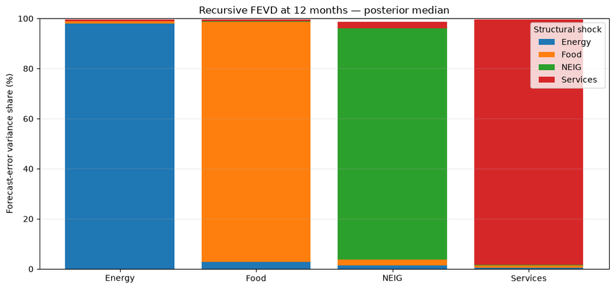

```python
if RUN_STRUCTURAL_ANALYSIS:
    fevd = forecast_error_variance_decomposition(
        structural_result,
        identification="recursive",
        horizon=STRUCTURAL_HORIZON,
        include_outlier_scale=False,
    )
    print("FEVD max adding-up error:", fevd["max_share_sum_error"])

    requested_horizons = [1, 3, 6, 12, 24]
    requested_horizons = [h for h in requested_horizons if h <= STRUCTURAL_HORIZON]
    rows = []
    shares = np.asarray(fevd["fevd_draws"], dtype=float)
    for h in requested_horizons:
        median_share = np.median(shares[:, h - 1, :, :], axis=0)
        for response_i, response_name in enumerate(fevd["variables"]):
            row = {
                "horizon_months": h,
                "response": structural_labels[response_name],
            }
            for shock_j, shock_name in enumerate(fevd["shock_names"]):
                row[f"shock_{structural_labels[shock_name]}"] = 100.0 * median_share[response_i, shock_j]
            rows.append(row)
    fevd_table = pd.DataFrame(rows).set_index(["horizon_months", "response"])
    display(style_numeric_table(fevd_table, caption="Recursive FEVD — posterior median shares (%)"))

    plot_h = 12 if STRUCTURAL_HORIZON >= 12 else STRUCTURAL_HORIZON
    plot_share = np.median(shares[:, plot_h - 1, :, :], axis=0)
    fig, ax = plt.subplots(figsize=(10.5, 5.0))
    x = np.arange(len(fevd["variables"]))
    bottom = np.zeros(len(x))
    for shock_j, shock_name in enumerate(fevd["shock_names"]):
        values = 100.0 * plot_share[:, shock_j]
        ax.bar(x, values, bottom=bottom, label=structural_labels[shock_name])
        bottom += values
    ax.set_xticks(x, [structural_labels[v] for v in fevd["variables"]])
    ax.set_ylabel("Forecast-error variance share (%)")
    ax.set_title(f"Recursive FEVD at {plot_h} months — posterior median")
    ax.set_ylim(0, 100)
    ax.grid(axis="y", alpha=0.25)
    ax.legend(title="Structural shock")
    fig.tight_layout()
    display(fig)
    plt.close(fig)
```

```
HD exact reconstruction max error: 6.245004513516506e-17
HD 12-month log-inflation adding-up max error: 8.615330671091215e-14
```

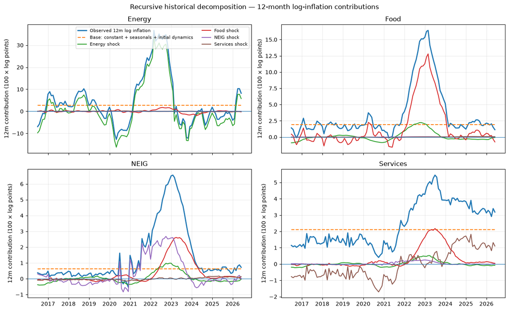

```python
if RUN_STRUCTURAL_ANALYSIS:
    hd = historical_decomposition(
        structural_result,
        identification="recursive",
        split_outlier_amplification=True,
        reconstruction_tol=1e-8,
    )
    print("HD exact reconstruction max error:", hd["max_reconstruction_error"])

    raw_contrib = np.asarray(hd["contributions"], dtype=float)
    n_shocks = len(hd["shock_names"])
    # Aggregate each shock's regular and outlier-amplification pieces back together
    # for a readable four-shock decomposition.
    shock_contrib = np.stack(
        [raw_contrib[..., 2 * j] + raw_contrib[..., 2 * j + 1] for j in range(n_shocks)],
        axis=-1,
    )
    base = np.asarray(hd["base"], dtype=float)
    observed = np.asarray(hd["observed"], dtype=float)
    dates = pd.DatetimeIndex(hd["dates"], name="date")

    def rolling_12_draws(x: np.ndarray) -> np.ndarray:
        # x: draws × time × ... ; exact 12-month sum of monthly log-change contributions.
        out = np.full_like(x, np.nan, dtype=float)
        csum = np.cumsum(x, axis=1)
        out[:, 11:] = csum[:, 11:]
        if x.shape[1] > 12:
            out[:, 12:] -= csum[:, :-12]
        return out

    def rolling_12_observed(x: np.ndarray) -> np.ndarray:
        # x: time × variables
        out = np.full_like(x, np.nan, dtype=float)
        csum = np.cumsum(x, axis=0)
        out[11:] = csum[11:]
        if x.shape[0] > 12:
            out[12:] -= csum[:-12]
        return out

    shock_yoy = 100.0 * rolling_12_draws(shock_contrib)
    base_yoy = 100.0 * rolling_12_draws(base)
    observed_yoy_log = 100.0 * rolling_12_observed(observed)

    # Draw-by-draw adding-up check after 12-month accumulation.
    reconstructed_yoy = base_yoy + np.nansum(shock_yoy, axis=3)
    mask = np.isfinite(reconstructed_yoy) & np.isfinite(observed_yoy_log[None, :, :])
    yoy_add_error = float(
        np.max(np.abs(reconstructed_yoy[mask] - np.broadcast_to(observed_yoy_log, reconstructed_yoy.shape)[mask]))
    )
    print("HD 12-month log-inflation adding-up max error:", yoy_add_error)

    start = max(0, len(dates) - int(HD_LAST_OBS))
    fig, axes = plt.subplots(2, 2, figsize=(13, 8.0), sharex=True)
    for response_i, (ax, response_name) in enumerate(zip(axes.ravel(), hd["variables"])):
        ax.plot(
            dates[start:],
            observed_yoy_log[start:, response_i],
            linewidth=2.0,
            label="Observed 12m log inflation",
        )
        base_median = np.nanmedian(base_yoy[:, :, response_i], axis=0)
        ax.plot(
            dates[start:],
            base_median[start:],
            linestyle="--",
            label="Base: constant + seasonals + initial dynamics",
        )
        for shock_j, shock_name in enumerate(hd["shock_names"]):
            contribution_median = np.nanmedian(
                shock_yoy[:, :, response_i, shock_j],
                axis=0,
            )
            ax.plot(
                dates[start:],
                contribution_median[start:],
                label=f"{structural_labels[shock_name]} shock",
            )
        ax.axhline(0.0, linewidth=0.8)
        ax.set_title(structural_labels[response_name])
        ax.set_ylabel("12m contribution (100 × log points)")
        ax.grid(alpha=0.25)
    axes.ravel()[0].legend(fontsize=8, ncol=2)
    fig.suptitle("Recursive historical decomposition — 12-month log-inflation contributions")
    fig.tight_layout()
    display(fig)
    plt.close(fig)
```

## 18. Only lag sensitivity: dense BVAR(6) versus dense BVAR(12)

No automatic lag-selection exercise is performed. The production baseline remains the seasonal dense BVAR(12); the only approved lag sensitivity is the same model with six dense endogenous lags and **the identical 11 monthly seasonal dummies**. This isolates lag-order sensitivity from deterministic-seasonality changes.

```python
if RUN_BVAR6_SENSITIVITY:
    result_6 = run_headline_joint_bvar(
        native_levels,
        vintage=VINTAGE_USED,
        p=SENSITIVITY_P,
        prior_config=PRIOR_CONFIG,
        sampler_config=SAMPLER_CONFIG,
        code_version="headline-joint-bvar6-seasonal-sensitivity-v1",
    )

    comparison = lag_comparison_table(
        {
            6: result_6,
            12: result_12,
        }
    )
    display(comparison)

    forecast_6 = forecast_headline_joint_bvar(
        result_6,
        native_levels=native_levels,
        H=FORECAST_HORIZON,
        n_draws=min(FORECAST_DRAWS, result_6["n_draws"]),
        simulate_future_outliers=True,
        seed=2026,
    )
    headline_forecast_6 = aggregate_headline_draws(
        forecast_6,
        native_levels=native_levels,
        weights=weights,
        official_total=official_total,
    )

    print("BVAR(6) + monthly dummies — Headline YoY")
    display(headline_forecast_table(headline_forecast_6, kind="yoy"))
else:
    print(
        "BVAR(6) sensitivity disabled. Set RUN_BVAR6_SENSITIVITY=True "
        "only after the canonical seasonal BVAR(12) run is validated."
    )
```

```
BVAR(6) sensitivity disabled. Set RUN_BVAR6_SENSITIVITY=True only after the canonical seasonal BVAR(12) run is validated.
```

## 19. Save canonical seasonal run to the shared registry

```python
if SAVE_RESULTS:
    if save_energy_bvar_result is None:
        raise RuntimeError("energy_bvar_io.save_energy_bvar_result is unavailable.")
    saved = save_energy_bvar_result(result_12, PROJECT_ROOT / "results")
    print("Saved canonical seasonal BVAR(12) run to:", saved["directory"])
else:
    print("SAVE_RESULTS=False — canonical seasonal run is not promoted to the registry.")
```

```
SAVE_RESULTS=False — canonical seasonal run is not promoted to the registry.
```

## Current production contract

```
Excel / Haver / Eurostat
        │
        ├─ HICP Energy
        ├─ HICP Food      (H023HA1@EUDATA)
        ├─ HICP NEIG
        └─ HICP Services
                ↓
       headline_joint_monthly.csv
                ↓
        all four → log state → Δlog
                +
        11 monthly seasonal dummies
        (December reference)
                ↓
        dense joint BVAR(12)
        Minnesota + SV + outliers + DK
                ↓
      joint posterior component paths
                ↓
     annual HICP component weights
        Food weight = PF + UF
                ↓
       December-rebased chain linking
                ↓
          Headline HICP posterior
                ↓
              dashboard
```

The same fitted BVAR also feeds the notebook's recursive structural block:

```
posterior B, A, stochastic volatility, outlier scales
                ↓
      recursive Cholesky ordering
 Energy → Food → NEIG → Services
                ↓
        IRF / FEVD / exact HD
```

Seasonal dummies remain deterministic throughout: they are not structural shocks and do not enter the companion dynamics. In the historical decomposition they are absorbed by the deterministic/base contribution.

Deferred decomposition models remain separate:

```
notebooks/decomposition/
    11 Unprocessed Food
    12 Processed Food
    13 NEIG
    14 Services
```

They are not required by the current joint Headline production pipeline.

Seasonal diagnostics are a sidecar to this production path, not an alternative transformation pipeline:

```
canonical BVAR(12) posterior
        │
        ├─ ADF / KPSS at frequency zero
        ├─ companion roots by posterior draw and seasonal frequency
        ├─ draw-by-draw equation localization
        └─ optional HEGY + Canova-Hansen on log levels
                  ↓
             diagnostic decision only
```

No diagnostic above automatically changes the endogenous transformation, applies seasonal differencing, or changes the stored canonical run.